# Aula 5 - Teste Final

# 1 Aula Final

Seja bem-vindo a quinta e última aula do nosso minicurso de Fundamentos de Processamento de Dados Utilizando o Tidyverse!

Parabéns, você concluiu a jornada!!

[figure not shown]

[Arte de @allison_horst](https://allisonhorst.com/allison-horst)

# 2 Mortalidade no Brasil

Os dados trabalhados nessa aula final foram retirados do [DAENT - Departamento de Análise Epidemiológica e Vigilância de Doenças Não Transmissíveis](https://svs.aids.gov.br/daent/centrais-de-conteudos/paineis-de-monitoramento/mortalidade/cid10/), sendo dados da mortalidade (CID-10)

- Nosso objetivo é ajustar os dados para uma análise estatística, onde desejamos comparar como os dados se apresentam nas diferentes regiões do Brasil.

Assim, as seguintes tabelas devem ser montadas

- Dados Base
  - Tabela base, com número de mortos por UF e por data. Deve conter chaves de referência para tabelas de UFs e Regiões
- Tabela UFs
  - Tabela com informações das UFs, deve conter uma chave de UF, chave de Região, nome da UF e posteriormente a população daquela UF
- Tabela Regiões
  - Tabela com informações das Regiões, deve conter uma chave de Região, nome da Região e posteriormente a população daquela Região

```r
library(tidyverse)
library(janitor)
```

## 2.1 Tabela de Dados Base

Os dados baixados possuem a seguinte aparência

```r
read_csv2(here::here('./conjunto_de_dados/cid10_2023.csv')) |>
  rmarkdown::paged_table()
```

| ano (uid) | ano (nome) | local (uid) | local (nome) | indicador (uid) | indicador (nome) | categoria (uid) | categoria (nome) | estatistica (uid) | estatistica (nome) | lococor (uid) | lococor (nome) | atestante (uid) | atestante (nome) | grupoetario (uid) | grupoetario (nome) | racacor (uid) | racacor (nome) | sexo (uid) | sexo (nome) | abrangencia (uid) | abrangencia (nome) | localidade (uid) | localidade (nome) | Janeiro | Fevereiro | Março | Abril | Maio | Junho | … |
| --- | --- | --- | --- | --- | --- | --- | --- | --- | --- | --- | --- | --- | --- | --- | --- | --- | --- | --- | --- | --- | --- | --- | --- | --- | --- | --- | --- | --- | --- | --- |
| 2023 | 2023* | 1 | Óbitos por residência | 200001 | Óbitos totais | 1 | Notificação de óbitos | 1 | Número de óbitos | 0 | Todos | 0 | Todos | 2000 | Todos | 0 | Todos | 0 | Todos | 1 | País | 76 | Brasil | 115993 | 103344 | 116179 | 106874 | 64099 | 196 | … |
| 2023 | 2023* | 1 | Óbitos por residência | 200001 | Óbitos totais | 1 | Notificação de óbitos | 1 | Número de óbitos | 0 | Todos | 0 | Todos | 2000 | Todos | 0 | Todos | 0 | Todos | 2 | Região | 1 | Norte | 7675 | 7115 | 7680 | 7338 | 5060 | 22 | … |
| 2023 | 2023* | 1 | Óbitos por residência | 200001 | Óbitos totais | 1 | Notificação de óbitos | 1 | Número de óbitos | 0 | Todos | 0 | Todos | 2000 | Todos | 0 | Todos | 0 | Todos | 3 | Unidade da federação | 11 | Rondônia | 801 | 684 | 807 | 824 | 642 | 2 | … |
| 2023 | 2023* | 1 | Óbitos por residência | 200001 | Óbitos totais | 1 | Notificação de óbitos | 1 | Número de óbitos | 0 | Todos | 0 | Todos | 2000 | Todos | 0 | Todos | 0 | Todos | 3 | Unidade da federação | 12 | Acre | 317 | 288 | 267 | 344 | 214 | 0 | … |
| 2023 | 2023* | 1 | Óbitos por residência | 200001 | Óbitos totais | 1 | Notificação de óbitos | 1 | Número de óbitos | 0 | Todos | 0 | Todos | 2000 | Todos | 0 | Todos | 0 | Todos | 3 | Unidade da federação | 13 | Amazonas | 1693 | 1569 | 1689 | 1370 | 362 | 0 | … |
| 2023 | 2023* | 1 | Óbitos por residência | 200001 | Óbitos totais | 1 | Notificação de óbitos | 1 | Número de óbitos | 0 | Todos | 0 | Todos | 2000 | Todos | 0 | Todos | 0 | Todos | 3 | Unidade da federação | 14 | Roraima | 249 | 227 | 262 | 250 | 152 | 0 | … |
| 2023 | 2023* | 1 | Óbitos por residência | 200001 | Óbitos totais | 1 | Notificação de óbitos | 1 | Número de óbitos | 0 | Todos | 0 | Todos | 2000 | Todos | 0 | Todos | 0 | Todos | 3 | Unidade da federação | 15 | Pará | 3513 | 3357 | 3642 | 3508 | 2924 | 20 | … |
| 2023 | 2023* | 1 | Óbitos por residência | 200001 | Óbitos totais | 1 | Notificação de óbitos | 1 | Número de óbitos | 0 | Todos | 0 | Todos | 2000 | Todos | 0 | Todos | 0 | Todos | 3 | Unidade da federação | 16 | Amapá | 333 | 318 | 299 | 287 | 161 | 0 | … |
| 2023 | 2023* | 1 | Óbitos por residência | 200001 | Óbitos totais | 1 | Notificação de óbitos | 1 | Número de óbitos | 0 | Todos | 0 | Todos | 2000 | Todos | 0 | Todos | 0 | Todos | 3 | Unidade da federação | 17 | Tocantins | 769 | 672 | 714 | 755 | 605 | 0 | … |
| 2023 | 2023* | 1 | Óbitos por residência | 200001 | Óbitos totais | 1 | Notificação de óbitos | 1 | Número de óbitos | 0 | Todos | 0 | Todos | 2000 | Todos | 0 | Todos | 0 | Todos | 2 | Região | 2 | Nordeste | 30272 | 27490 | 29867 | 27071 | 13507 | 78 | … |

[output cut: 23 more lines]

Iremos construir as colunas: data, nome da uf, codigo do IBGE da UF e número de mortes

```r
df_cid10_uf = read_csv2(here::here('./conjunto_de_dados/cid10_2023.csv')) |>
  clean_names() |>
  select('abrangencia_nome':'junho') |>
  pivot_longer('janeiro':'junho') |>
  mutate(name =
           case_when(name ==  'janeiro' ~ '2023-01-01',
                     name ==  'fevereiro' ~ '2023-02-01',
                     name ==  'marco' ~ '2023-03-01',
                     name ==  'abril' ~ '2023-04-01',
                     name ==  'maio' ~ '2023-05-01',
                     name ==  'junho' ~ '2023-06-01')) |>
  rename(data = name,
         mortes_cid10 = value) |>
  dplyr::filter(abrangencia_nome == 'Unidade da federação') |>
  rename(cod_uf = localidade_uid,
         uf_nome = localidade_nome) |>
  select(data,
         uf_nome,
         cod_uf,
         mortes_cid10) |>
  mutate(data = data |>
           lubridate::ymd()) |>
  mutate(uf_nome = uf_nome |>
           stringr::str_replace_all(' ', "_") |>
           tolower() |>
           abjutils::rm_accent()
        )

df_cid10_uf |>
  rmarkdown::paged_table()
```

| data | uf_nome | cod_uf | mortes_cid10 |
| --- | --- | --- | --- |
| 2023-01-01 | rondonia | 11 | 801 |
| 2023-02-01 | rondonia | 11 | 684 |
| 2023-03-01 | rondonia | 11 | 807 |
| 2023-04-01 | rondonia | 11 | 824 |
| 2023-05-01 | rondonia | 11 | 642 |
| 2023-06-01 | rondonia | 11 | 2 |
| 2023-01-01 | acre | 12 | 317 |
| 2023-02-01 | acre | 12 | 288 |
| 2023-03-01 | acre | 12 | 267 |
| 2023-04-01 | acre | 12 | 344 |

[output cut: 152 more lines]

## 2.2 Tabela de Municípios e UFs

- UFs

```r
library(rvest)
url = rvest::read_html('https://www.ibge.gov.br/explica/codigos-dos-municipios.php')

tbl_ufs =
  tibble(
  uf = url|>
      rvest::html_nodes('.uf td:nth-child(1) a')|>
      rvest::html_text() |>
      stringr::str_replace_all(' ', "_"),
  cod_uf = url|>
      rvest::html_nodes('.numero a')|>
      rvest::html_text()
) |>
  dplyr::mutate(
    cod_uf = cod_uf |>
      stringr::str_remove('ver municípios') |>
      as.numeric(),
    uf = uf |>
      tolower() |>
      abjutils::rm_accent()
    ) |>
  mutate(cod_reg = cod_uf |>
           as.character() |>
           stringr::str_sub(1,1) |>
           as.numeric())
```

- Tabela de Regiões

```r
tbl_regs =
  tibble(reg =
         c('norte',
           'nordeste',
           'sudeste',
           'sul',
           'centro_oeste'),
       cod_reg =
         c(1,2,3,4,5))
```

# 3 Realizando a Análise

```r
df_cid10_regs =
  df_cid10_uf |>
  inner_join(tbl_ufs, by = 'cod_uf') |>
  inner_join(tbl_regs, by = 'cod_reg') |>
  group_by(data, reg, cod_reg) |>
  summarise(mortes_cid10 = sum(mortes_cid10))
```

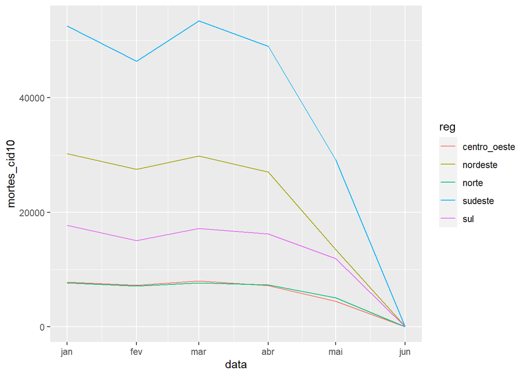

```r
df_cid10_regs |>
  ggplot(aes(x = data, y = mortes_cid10, color = reg)) +
  geom_line()
```

Se desejássemos realizar um ajuste via tamanho populacional

# 4 Adicionando População

Ajustando as tabelas de UFs e Regiões para terem a informação de tamanho populacional

```r
pop_estim_uf = readxl::read_xls(here::here('./conjunto_de_dados/pop_2023.xls'),
                 n_max = 35) |>
  row_to_names(1) |>
  remove_empty(which = 'cols') |>
  clean_names() |>
  filter(brasil_e_unidades_da_federacao |>
           stringr::str_detect('Região') == F &
        brasil_e_unidades_da_federacao |>
           stringr::str_detect('Brasil') == F) |>
  rename(uf = brasil_e_unidades_da_federacao,
         pop = populacao_estimada) |>
  mutate(uf = uf |>
           abjutils::rm_accent() |>
           tolower()|>
           stringr::str_replace_all(' ', "_")) |>
  mutate(pop = pop |>
           stringr::str_remove_all('\\(\\d+\\)') |>
           stringr::str_remove_all('\\.') |>
           as.numeric()
         )


pop_estim_uf |>
  rmarkdown::paged_table()
```

| uf | pop |
| --- | --- |
| rondonia | 1815278 |
| acre | 906876 |
| amazonas | 4269995 |
| roraima | 652713 |
| para | 8777124 |
| amapa | 877613 |
| tocantins | 1607363 |
| maranhao | 7153262 |
| piaui | 3289290 |
| ceara | 9240580 |

[output cut: 17 more lines]

```r
tbl_ufs_pop = tbl_ufs |>
  inner_join(pop_estim_uf, by = 'uf')

tbl_ufs_pop |>
  rmarkdown::paged_table()
```

| uf | cod_uf | cod_reg | pop |
| --- | --- | --- | --- |
| acre | 12 | 1 | 906876 |
| alagoas | 27 | 2 | 3365351 |
| amapa | 16 | 1 | 877613 |
| amazonas | 13 | 1 | 4269995 |
| bahia | 29 | 2 | 14985284 |
| ceara | 23 | 2 | 9240580 |
| distrito_federal | 53 | 5 | 3094325 |
| espirito_santo | 32 | 3 | 4108508 |
| goias | 52 | 5 | 7206589 |
| maranhao | 21 | 2 | 7153262 |

[output cut: 17 more lines]

```r
tbl_regs_pop = tbl_ufs_pop |>
  group_by(cod_reg) |>
  summarise(pop = sum(pop)) |>
  inner_join(tbl_regs, by = 'cod_reg') |>
  relocate(reg, .before = pop)


tbl_regs_pop |>
  rmarkdown::paged_table()
```

| cod_reg | reg | pop |
| --- | --- | --- |
| 1 | norte | 18906962 |
| 2 | nordeste | 57667842 |
| 3 | sudeste | 89632912 |
| 4 | sul | 30402587 |
| 5 | centro_oeste | 16707336 |

```r
df_cid10_regs =
  df_cid10_uf |>
  inner_join(tbl_ufs_pop, by = 'cod_uf') |>
  inner_join(tbl_regs_pop, by = 'cod_reg') |>
  group_by(data, reg, cod_reg) |>
  summarise(mortes_cid10 = sum(mortes_cid10)) |>
  inner_join(tbl_regs_pop, by = 'cod_reg') |>
  ungroup()

df_cid10_regs |>
  rmarkdown::paged_table()
```

| data | reg.x | cod_reg | mortes_cid10 | reg.y | pop |
| --- | --- | --- | --- | --- | --- |
| 2023-01-01 | centro_oeste | 5 | 7812 | centro_oeste | 16707336 |
| 2023-01-01 | nordeste | 2 | 30272 | nordeste | 57667842 |
| 2023-01-01 | norte | 1 | 7675 | norte | 18906962 |
| 2023-01-01 | sudeste | 3 | 52521 | sudeste | 89632912 |
| 2023-01-01 | sul | 4 | 17713 | sul | 30402587 |
| 2023-02-01 | centro_oeste | 5 | 7281 | centro_oeste | 16707336 |
| 2023-02-01 | nordeste | 2 | 27490 | nordeste | 57667842 |
| 2023-02-01 | norte | 1 | 7115 | norte | 18906962 |
| 2023-02-01 | sudeste | 3 | 46382 | sudeste | 89632912 |
| 2023-02-01 | sul | 4 | 15076 | sul | 30402587 |

[output cut: 20 more lines]

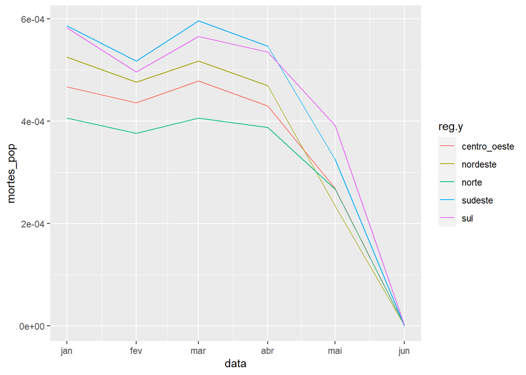

```r
df_cid10_regs |>
  mutate(mortes_pop = mortes_cid10/pop) |>
  ggplot(aes(x = data, y = mortes_pop, color = reg.y)) +
  geom_line()
```

# 5 Chegou Sua Vez

Agora o bastão está com você, estude alguma região do seu interesse. Prepare os dados dos estados dessa região, adicionando variáveis de seu interesse para melhor estudar a variável mortalidade

A tarefa será aberta de maneira oficial na quarta-feira(20), onde você terá uma mês para realizá-la.

Aproveite esse tempo para estudar, e lembre-se, qualquer dúvida, é so me mandar um email.

Muito obrigado pela parceira durante essas 2 semanas!

Abraços e boas festas. Gustavo